# Workshop 3

Equipo 7

2022-06-17

#### **Equipo 7:**

- Daniela Patricia Saucedo Sánchez
- Ethan Aguilera Ortiz
- Jesús Mesta Fraustro
- José Gabriel Usiña Mogro
- Pedro Gómez Bravo

# Preparar la Base de Datos

```r
BD<-read_excel("BD CRIT.xlsx")
```

```r
sum(is.na(BD))
```

```
## [1] 0
```

```r
colSums(is.na(BD))
```

```
##                  Tecnología y Equipo                  Vestimenta Personal
##                                    0                                    0
##                   Pin Identificación                           Mobiliario
##                                    0                                    0
##                              Empatía                            Confianza
##                                    0                                    0
##                          Necesidades                      Responder Dudas
##                                    0                                    0
##                   Cortesía/Educación           Capacidades Administración
##                                    0                                    0
##                   Capacidades Médico                   Instrumentos Citas
##                                    0                                    0
##                    Tiempo y Duración          Eficiencia Sistema de Citas
##                                    0                                    0
##              Reprogramación de Citas                      Profesionalismo
##                                    0                                    0
##                Instrucciones Médicas             Seguimiento del paciente
##                                    0                                    0
##                   Interés del médico                   Tiempo de Atención
##                                    0                                    0
##                     Tiempo de espera           Tiempo Médico Especialista
##                                    0                                    0
##            Tiempo Médico Acompañante                      Tiempo Terapias
##                                    0                                    0
##                          Cancelación                 Razón de Cancelación
##                                    0                                    0
##                  En caso de cancelar                 Tipo de Institucipon
##                                    0                                    0
##                             Donativo              Disponibilidad a apoyar
##                                    0                                    0
##          Disponibilidad a participar                         Calificación
##                                    0                                    0
##                                Fecha                                 Hora
##                                    0                                    0
##                   Medio de Respuesta Consulta Médica/Valoraciones Médicas
##                                    0                                    0
##                       Terapia Física                  Terapia Ocupacional
##                                    0                                    0
##                  Terapia de Lenguaje                         Hidroterapia
##                                    0                                    0
##                                Otros                       Edad Respuesta
##                                    0                                    0
##                        Edad Paciente                                Folio
##                                    0                                    0
##                    Nivel de Estudios             Relación con el Paciente
##                                    0                                    0
##                     Género Respuesta
##                                    0
```

```r
BD_numeric<-BD%>%select_if(is.numeric) #Nos servirá para realizar el análisis de factores
```

```r
BD$`Tecnología y Equipo`<-as.factor(BD$`Tecnología y Equipo`)
BD$`Vestimenta Personal`<-as.factor(BD$`Vestimenta Personal`)
BD$`Pin Identificación`<-as.factor(BD$`Pin Identificación`)
BD$Mobiliario<-as.factor(BD$Mobiliario)
BD$Empatía<-as.factor(BD$Empatía)
BD$Confianza<-as.factor(BD$Confianza)
BD$Necesidades<-as.factor(BD$Necesidades)
BD$`Responder Dudas`<-as.factor(BD$`Responder Dudas`)
BD$`Cortesía/Educación`<-as.factor(BD$`Cortesía/Educación`)
BD$`Capacidades Administración`<-as.factor(BD$`Capacidades Administración`)
BD$`Capacidades Médico`<-as.factor(BD$`Capacidades Médico`)
BD$`Instrumentos Citas`<-as.factor(BD$`Instrumentos Citas`)
BD$`Tiempo y Duración`<-as.factor(BD$`Tiempo y Duración`)
BD$`Eficiencia Sistema de Citas`<-(BD$`Eficiencia Sistema de Citas`)
BD$`Reprogramación de Citas`<-(BD$`Reprogramación de Citas`)
BD$Profesionalismo<-as.factor(BD$Profesionalismo)
BD$`Instrucciones Médicas`<-as.factor(BD$`Instrucciones Médicas`)
BD$`Seguimiento del paciente`<-as.factor(BD$`Seguimiento del paciente`)
BD$`Interés del médico`<-as.factor(BD$`Interés del médico`)
BD$`Tiempo de Atención`<-as.factor(BD$`Tiempo de Atención`)
BD$`Tiempo de espera`<-as.factor(BD$`Tiempo de espera`)
BD$`Tiempo Médico Especialista`<-as.factor(BD$`Tiempo Médico Especialista`)
BD$`Tiempo Médico Acompañante`<-as.factor(BD$`Tiempo Médico Acompañante`)
BD$`Tiempo Terapias`<-as.factor(BD$`Tiempo Terapias`)
BD$Cancelación<-as.factor(BD$Cancelación)
BD$`Razón de Cancelación`<-as.factor(BD$`Razón de Cancelación`)
BD$`En caso de cancelar`<-as.factor(BD$`En caso de cancelar`)
BD$`Tipo de Institucipon`<-as.factor(BD$`Tipo de Institucipon`)
BD$Donativo<-as.factor(BD$Donativo)
BD$`Disponibilidad a apoyar`<-as.factor(BD$`Disponibilidad a apoyar`)
BD$`Disponibilidad a participar`<-as.factor(BD$`Disponibilidad a participar`)
BD$`Medio de Respuesta`<-as.factor(BD$`Medio de Respuesta`)
BD$`Terapia Física`<-as.factor(BD$`Terapia Física`)
BD$`Terapia de Lenguaje`<-as.factor(BD$`Terapia de Lenguaje`)
BD$`Terapia Ocupacional`<-as.factor(BD$`Terapia Ocupacional`)
BD$Hidroterapia<-as.factor(BD$Hidroterapia)
BD$Otros<-as.factor(BD$Otros)
BD$`Nivel de Estudios`<-as.factor(BD$`Nivel de Estudios`)
BD$`Relación con el Paciente`<-as.factor(BD$`Relación con el Paciente`)
BD$`Género Respuesta`<-as.factor(BD$`Género Respuesta`)
```

# ANOVA

Realizar una prueba ANOVA para comprobar si la calificación otorgada al CRIT es diferente dependiendo de la confianza.

- Hipotesis Nula (Ho):calificación igual
- Hipotesis Alternativa (Ha): calificación distinta

```r
prueba <- one_way_model_1<-aov(Calificación~Confianza, data=BD)
summary(prueba)
```

```
##              Df Sum Sq Mean Sq F value   Pr(>F)
## Confianza     4  2.741  0.6852   5.545 0.000301 ***
## Residuals   194 23.973  0.1236
## ---
## Signif. codes:  0 '***' 0.001 '**' 0.01 '*' 0.05 '.' 0.1 ' ' 1
```

No se acepta la hipotesis nula ya que el valor de p es menor al 10%. Con esto se concluye que las calificaciones dadas al CRIT si tienen una relación con la confianza que los clientes perciban por parte de los médicos

# Chi Cuadrada

### Primera Prueba

#### RELACIÓN ENTRE LA DISPONIBILIDAD DE LOS PACIENTES A PARTICIPAR EN CAMPAÑAS PARA INCENETIVAR DONATIVOS Y CAMPAÑAS DE COMUNICACIÓN.

```r
apoyo_table=table(BD$`Disponibilidad a apoyar`,BD$`Disponibilidad a participar`)
apoyo_table
```

```
##
##       No  Sí
##   No   5   5
##   Sí  27 162
```

```r
chisq.test(apoyo_table)
```

```
##
##  Pearson's Chi-squared test with Yates' continuity correction
##
## data:  apoyo_table
## X-squared = 6.5255, df = 1, p-value = 0.01063
```

Podemos observar en la tabla la distribución de los pacientes que están dispuestos a dona, y los pacientes que están dispuestos a participar en campañas de comunicación.

### Segunda Prueba

**DISPONIBILIDAD QUE TIENEN LOS PACIENTES A REALIZAR UN DONATIVO A LA ORGANIZACIÓN DE ACUERDO A SU TIPO DE TERAPIA**

#### Disponibilidad a donar de los pacientes de terapía física

```r
fis_table=table(BD$Donativo,BD$`Terapia Física`)
fis_table
```

```
##
##       No  Si
##   No   2  43
##   Sí   6 148
```

```r
chisq.test(fis_table)
```

```
##
##  Pearson's Chi-squared test with Yates' continuity correction
##
## data:  fis_table
## X-squared = 8.5125e-30, df = 1, p-value = 1
```

#### Disponibilidad a donar de los pacientes de terapía ocupacional

```r
ocu_table=table(BD$Donativo,BD$`Terapia Ocupacional`)
ocu_table
```

```
##
##       No  Si
##   No   8  37
##   Sí  22 132
```

```r
chisq.test(ocu_table)
```

```
##
##  Pearson's Chi-squared test with Yates' continuity correction
##
## data:  ocu_table
## X-squared = 0.11501, df = 1, p-value = 0.7345
```

#### Disponibilidad a donar de los pacientes de terapía de lenguaje

```r
len_table=table(BD$Donativo,BD$`Terapia de Lenguaje`)
len_table
```

```
##
##       No  Si
##   No  18  27
##   Sí  49 105
```

```r
chisq.test(len_table)
```

```
##
##  Pearson's Chi-squared test with Yates' continuity correction
##
## data:  len_table
## X-squared = 0.70963, df = 1, p-value = 0.3996
```

#### Disponibilidad a donar de los pacientes de Hidfroterapía

```r
hidro_table=table(BD$Donativo,BD$Hidroterapia)
hidro_table
```

```
##
##      No Si
##   No 29 16
##   Sí 65 89
```

```r
chisq.test(hidro_table)
```

```
##
##  Pearson's Chi-squared test with Yates' continuity correction
##
## data:  hidro_table
## X-squared = 6.0455, df = 1, p-value = 0.01394
```

Tras contrastar los 4 diferentes tipos de terapia que se brindan, podemos observar que el único análisis en el que se rechaza la hipótesis nula es en los pacientes de hidroterapia, en donde el p value obtenido es del del 1.3% ; mientras que los pacientes de terapia ocupacional terapia física y terapía de lenguaje no muestran una relación entre esta variable y la disposición que tienen estos pacientes a realizar un donativo a la organización.

# Regresión Lineal Múltiple

## Análisis de Factores

```r
cortest.bartlett(BD_numeric)
```

```
## R was not square, finding R from data
```

```
## $chisq
## [1] 2720.299
##
## $p.value
## [1] 0
##
## $df
## [1] 231
```

Podemos continuar con el análisis

```r
KMO(BD_numeric)
```

```
## Kaiser-Meyer-Olkin factor adequacy
## Call: KMO(r = BD_numeric)
## Overall MSA =  0.92
## MSA for each item =
##         Tecnología y Equipo         Vestimenta Personal
##                        0.90                        0.96
##          Pin Identificación                  Mobiliario
##                        0.96                        0.95
##                     Empatía                   Confianza
##                        0.92                        0.91
##                 Necesidades             Responder Dudas
##                        0.87                        0.96
##          Cortesía/Educación  Capacidades Administración
##                        0.95                        0.93
##          Capacidades Médico          Instrumentos Citas
##                        0.92                        0.89
##           Tiempo y Duración Eficiencia Sistema de Citas
##                        0.95                        0.89
##     Reprogramación de Citas             Profesionalismo
##                        0.82                        0.95
##       Instrucciones Médicas    Seguimiento del paciente
##                        0.92                        0.96
##          Interés del médico                Calificación
##                        0.95                        0.81
##              Edad Respuesta               Edad Paciente
##                        0.41                        0.41
```

Calificación será nuestra variable dependiente, por lo que para el análisis de factores la excluiremos

```r
BD_alt<-subset(BD_numeric, select=-c(Calificación))
```

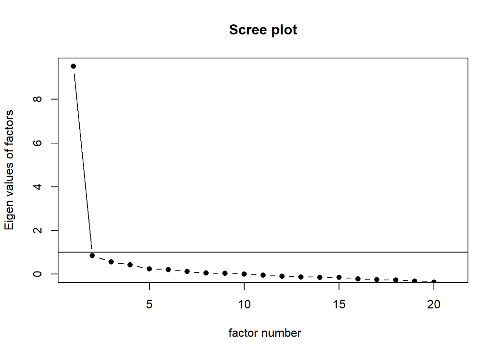

```r
ev_BD<-eigen(cor(BD_alt)) # get eigenvalues
scree(BD_alt,pc=FALSE)
```

```r
fa_3<-fa(BD_alt, nfactors=2) ### exploratory factor analysis
summary(fa_3)
```

```
##
## Factor analysis with Call: fa(r = BD_alt, nfactors = 2)
##
## Test of the hypothesis that 2 factors are sufficient.
## The degrees of freedom for the model is 169  and the objective function was  2.24
## The number of observations was  199  with Chi Square =  423.75  with prob <  7.4e-24
##
## The root mean square of the residuals (RMSA) is  0.05
## The df corrected root mean square of the residuals is  0.06
##
## Tucker Lewis Index of factoring reliability =  0.87
## RMSEA index =  0.087  and the 10 % confidence intervals are  0.077 0.098
## BIC =  -470.81
##  With factor correlations of
##      MR1  MR2
## MR1 1.00 0.64
## MR2 0.64 1.00
```

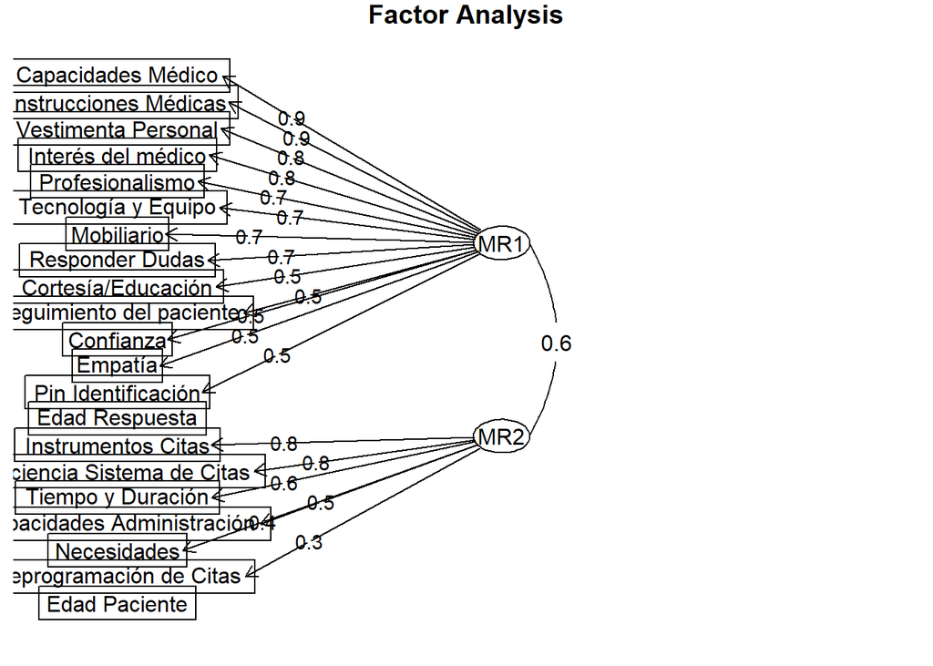

```r
fa.diagram(fa_3) ### get a diagram displaying the major loading on each factor
```

```r
fa_3$Vaccounted  ### get the amount of variance explained by each factor
```

```
##                             MR1       MR2
## SS loadings           7.0689563 3.4782440
## Proportion Var        0.3366170 0.1656307
## Cumulative Var        0.3366170 0.5022476
## Proportion Explained  0.6702211 0.3297789
## Cumulative Proportion 0.6702211 1.0000000
```

Se usarán solo dos factores, debido a que si usamos 3, uno de ellos solo engloba la edad del paciente y de quien respone la encuesta, haciendo algo no muy eficiente.

## Regresión Lineal

```r
regression_data<-cbind(BD_numeric$Calificación,fa_3$scores)
colnames(regression_data)<-c("Score","Atención Médica","Atención Administrativa")
regression_data<-data.frame(regression_data)
reg_model = lm(Score~.,regression_data)
summary(reg_model)
```

```
##
## Call:
## lm(formula = Score ~ ., data = regression_data)
##
## Residuals:
##      Min       1Q   Median       3Q      Max
## -2.65015  0.02985  0.03068  0.07136  1.18151
##
## Coefficients:
##                         Estimate Std. Error t value Pr(>|t|)
## (Intercept)             9.919598   0.024936 397.810  < 2e-16 ***
## Atención.Médica         0.110719   0.036480   3.035  0.00273 **
## Atención.Administrativa 0.005474   0.037680   0.145  0.88464
## ---
## Signif. codes:  0 '***' 0.001 '**' 0.01 '*' 0.05 '.' 0.1 ' ' 1
##
## Residual standard error: 0.3518 on 196 degrees of freedom
## Multiple R-squared:  0.09215,    Adjusted R-squared:  0.08289
## F-statistic: 9.947 on 2 and 196 DF,  p-value: 7.68e-05
```

Podemos ver que el factor que tiene más impacto en la calificación es de Atención Médica

A continuación usaremos las variables de cada uno de los factores, para realizar un análisis de regresión lineal y ver su relación con nuestra variable dependiente

### Atención Administrativa

```r
model_1=lm(Calificación~`Instrumentos Citas`+`Eficiencia Sistema de Citas`+`Tiempo y Duración`+`Capacidades Administración`+Necesidades+`Reprogramación de Citas`,data=BD)
summary(model_1)
```

```
##
## Call:
## lm(formula = Calificación ~ `Instrumentos Citas` + `Eficiencia Sistema de Citas` +
##     `Tiempo y Duración` + `Capacidades Administración` + Necesidades +
##     `Reprogramación de Citas`, data = BD)
##
## Residuals:
##      Min       1Q   Median       3Q      Max
## -1.96421  0.02942  0.04216  0.04216  0.92802
##
## Coefficients: (2 not defined because of singularities)
##                                Estimate Std. Error t value Pr(>|t|)
## (Intercept)                    9.849824   0.347458  28.348  < 2e-16 ***
## `Instrumentos Citas`2          0.019785   0.455177   0.043    0.965
## `Instrumentos Citas`3         -0.166991   0.417335  -0.400    0.690
## `Instrumentos Citas`4         -0.245259   0.362683  -0.676    0.500
## `Instrumentos Citas`5         -0.290966   0.362644  -0.802    0.423
## `Eficiencia Sistema de Citas`  0.017666   0.045969   0.384    0.701
## `Tiempo y Duración`2                 NA         NA      NA       NA
## `Tiempo y Duración`3           0.267628   0.521555   0.513    0.608
## `Tiempo y Duración`4           0.012734   0.446860   0.028    0.977
## `Tiempo y Duración`5           0.203612   0.456362   0.446    0.656
## `Capacidades Administración`3 -1.801444   0.321258  -5.607 7.38e-08 ***
## `Capacidades Administración`4 -0.007051   0.087847  -0.080    0.936
## `Capacidades Administración`5        NA         NA      NA       NA
## Necesidades4                   0.143961   0.153009   0.941    0.348
## Necesidades5                   0.138877   0.145621   0.954    0.341
## `Reprogramación de Citas`     -0.006367   0.018412  -0.346    0.730
## ---
## Signif. codes:  0 '***' 0.001 '**' 0.01 '*' 0.05 '.' 0.1 ' ' 1
##
## Residual standard error: 0.3149 on 185 degrees of freedom
## Multiple R-squared:  0.3133, Adjusted R-squared:  0.265
## F-statistic: 6.491 on 13 and 185 DF,  p-value: 4.225e-10
```

```r
stargazer(model_1,type="text",title="Atención Administrativa",single.row=TRUE,ci=FALSE,ci.level=0.9) ### present OLS Regression results in text forma
```

```
##
## Atención Administrativa
## =========================================================
##                                   Dependent variable:
##                               ---------------------------
##                                      Calificación
## ---------------------------------------------------------
## `Instrumentos Citas`2                0.020 (0.455)
## `Instrumentos Citas`3               -0.167 (0.417)
## `Instrumentos Citas`4               -0.245 (0.363)
## `Instrumentos Citas`5               -0.291 (0.363)
## `Eficiencia Sistema de Citas`        0.018 (0.046)
## `Tiempo y Duración`2
## `Tiempo y Duración`3                 0.268 (0.522)
## `Tiempo y Duración`4                 0.013 (0.447)
## `Tiempo y Duración`5                 0.204 (0.456)
## `Capacidades Administración`3      -1.801*** (0.321)
## `Capacidades Administración`4       -0.007 (0.088)
## `Capacidades Administración`5
## Necesidades4                         0.144 (0.153)
## Necesidades5                         0.139 (0.146)
## `Reprogramación de Citas`           -0.006 (0.018)
## Constant                           9.850*** (0.347)
## ---------------------------------------------------------
## Observations                              199
## R2                                       0.313
## Adjusted R2                              0.265
## Residual Std. Error                0.315 (df = 185)
## F Statistic                     6.491*** (df = 13; 185)
## =========================================================
## Note:                         *p<0.1; **p<0.05; ***p<0.01
```

### Atención Médica

```r
model_2 <- lm(Calificación ~ `Capacidades Médico` + `Instrucciones Médicas` + `Vestimenta Personal` + `Interés del médico` + Profesionalismo + `Tecnología y Equipo` + Mobiliario + `Responder Dudas` + `Cortesía/Educación` + `Seguimiento del paciente` + Confianza + Empatía + `Pin Identificación`, data = BD)

summary(model_2)
```

```
##
## Call:
## lm(formula = Calificación ~ `Capacidades Médico` + `Instrucciones Médicas` +
##     `Vestimenta Personal` + `Interés del médico` + Profesionalismo +
##     `Tecnología y Equipo` + Mobiliario + `Responder Dudas` +
##     `Cortesía/Educación` + `Seguimiento del paciente` + Confianza +
##     Empatía + `Pin Identificación`, data = BD)
##
## Residuals:
##      Min       1Q   Median       3Q      Max
## -1.32051  0.01155  0.01908  0.01908  0.70331
##
## Coefficients: (17 not defined because of singularities)
##                              Estimate Std. Error t value Pr(>|t|)
## (Intercept)                 10.000000   0.209177  47.806  < 2e-16 ***
## `Capacidades Médico`3       -0.971407   0.555974  -1.747 0.082405 .
## `Capacidades Médico`4       -0.798511   0.644622  -1.239 0.217154
## `Capacidades Médico`5       -0.915249   0.655591  -1.396 0.164515
## `Instrucciones Médicas`3    -1.908747   0.343911  -5.550 1.08e-07 ***
## `Instrucciones Médicas`4     0.890054   0.696129   1.279 0.202789
## `Instrucciones Médicas`5     0.896167   0.687630   1.303 0.194245
## `Vestimenta Personal`3             NA         NA      NA       NA
## `Vestimenta Personal`4       0.077330   0.078025   0.991 0.323053
## `Vestimenta Personal`5             NA         NA      NA       NA
## `Interés del médico`3        2.802825   0.432574   6.479 9.56e-10 ***
## `Interés del médico`4       -0.023935   0.066083  -0.362 0.717650
## `Interés del médico`5              NA         NA      NA       NA
## Profesionalismo3                   NA         NA      NA       NA
## Profesionalismo4            -0.188234   0.075503  -2.493 0.013621 *
## Profesionalismo5                   NA         NA      NA       NA
## `Tecnología y Equipo`2             NA         NA      NA       NA
## `Tecnología y Equipo`3      -0.660410   0.117262  -5.632 7.24e-08 ***
## `Tecnología y Equipo`4      -0.013426   0.049126  -0.273 0.784961
## `Tecnología y Equipo`5             NA         NA      NA       NA
## Mobiliario3                  0.062512   0.238428   0.262 0.793496
## Mobiliario4                  0.061143   0.061649   0.992 0.322707
## Mobiliario5                        NA         NA      NA       NA
## `Responder Dudas`2                 NA         NA      NA       NA
## `Responder Dudas`3          -0.684230   0.166906  -4.099 6.40e-05 ***
## `Responder Dudas`4          -0.114647   0.060905  -1.882 0.061490 .
```

[output cut: 11 more lines]

```
## Confianza5                         NA         NA      NA       NA
## Empatía2                           NA         NA      NA       NA
## Empatía3                    -0.003693   0.126826  -0.029 0.976806
## Empatía4                    -0.019443   0.050212  -0.387 0.699076
## Empatía5                           NA         NA      NA       NA
## `Pin Identificación`2       -0.868382   0.234525  -3.703 0.000288 ***
## `Pin Identificación`3        0.300857   0.173008   1.739 0.083850 .
## `Pin Identificación`4        0.007528   0.047547   0.158 0.874391
## `Pin Identificación`5              NA         NA      NA       NA
## ---
## Signif. codes:  0 '***' 0.001 '**' 0.01 '*' 0.05 '.' 0.1 ' ' 1
##
## Residual standard error: 0.2092 on 170 degrees of freedom
## Multiple R-squared:  0.7216, Adjusted R-squared:  0.6757
## F-statistic: 15.73 on 28 and 170 DF,  p-value: < 2.2e-16
```

```r
stargazer(model_2,type="text",title="Atención Médica",single.row=TRUE,ci=FALSE,ci.level=0.9) ### present OLS Regression results in text forma
```

```
##
## Atención Médica
## =======================================================
##                                 Dependent variable:
##                             ---------------------------
##                                    Calificación
## -------------------------------------------------------
## `Capacidades Médico`3             -0.971* (0.556)
## `Capacidades Médico`4             -0.799 (0.645)
## `Capacidades Médico`5             -0.915 (0.656)
## `Instrucciones Médicas`3         -1.909*** (0.344)
## `Instrucciones Médicas`4           0.890 (0.696)
## `Instrucciones Médicas`5           0.896 (0.688)
## `Vestimenta Personal`3
## `Vestimenta Personal`4             0.077 (0.078)
## `Vestimenta Personal`5
## `Interés del médico`3            2.803*** (0.433)
## `Interés del médico`4             -0.024 (0.066)
## `Interés del médico`5
## Profesionalismo3
## Profesionalismo4                 -0.188** (0.076)
## Profesionalismo5
## `Tecnología y Equipo`2
## `Tecnología y Equipo`3           -0.660*** (0.117)
## `Tecnología y Equipo`4            -0.013 (0.049)
## `Tecnología y Equipo`5
## Mobiliario3                        0.063 (0.238)
## Mobiliario4                        0.061 (0.062)
## Mobiliario5
## `Responder Dudas`2
## `Responder Dudas`3               -0.684*** (0.167)
## `Responder Dudas`4                -0.115* (0.061)
## `Responder Dudas`5
## `Cortesía/Educación`3            -3.087*** (0.320)
## `Cortesía/Educación`4             -0.013 (0.075)
## `Cortesía/Educación`5
## `Seguimiento del paciente`2        0.019 (0.210)
## `Seguimiento del paciente`3      -0.398*** (0.134)
## `Seguimiento del paciente`4        0.056 (0.064)
## `Seguimiento del paciente`5
## Confianza2
## Confianza3                         0.023 (0.244)
## Confianza4                         0.024 (0.066)
## Confianza5
## Empatía2
## Empatía3                          -0.004 (0.127)
## Empatía4                          -0.019 (0.050)
## Empatía5
## `Pin Identificación`2            -0.868*** (0.235)
## `Pin Identificación`3             0.301* (0.173)
## `Pin Identificación`4              0.008 (0.048)
## `Pin Identificación`5
## Constant                         10.000*** (0.209)
## -------------------------------------------------------
## Observations                            199
## R2                                     0.722
## Adjusted R2                            0.676
## Residual Std. Error              0.209 (df = 170)
## F Statistic                  15.733*** (df = 28; 170)
## =======================================================
## Note:                       *p<0.1; **p<0.05; ***p<0.01
```

Se puede observar que si existe relación significativa con las variables que se englobaron en el factor al que llamamos Atención Médica. En este análisis de Regresión se pudo observar que tiene más variables significativas que el análisis de Atención Administrativa, por ello podríamos decir que la Atención Médica influye mucho más en la experiencia del usuario

### Modelo de Regresión 3

Para este último modelo seleccionaremos diferentes variables, sin basarnos en el análisis de factores.

```r
model_3<-lm(Calificación~Mobiliario+`Eficiencia Sistema de Citas`+`Tecnología y Equipo`,data=BD)
summary(model_3)
```

```
##
## Call:
## lm(formula = Calificación ~ Mobiliario + `Eficiencia Sistema de Citas` +
##     `Tecnología y Equipo`, data = BD)
##
## Residuals:
##      Min       1Q   Median       3Q      Max
## -2.72224  0.01731  0.01731  0.07522  0.76409
##
## Coefficients: (1 not defined because of singularities)
##                               Estimate Std. Error t value Pr(>|t|)
## (Intercept)                    9.94209    0.32699  30.405  < 2e-16 ***
## Mobiliario3                   -0.23166    0.47870  -0.484  0.62899
## Mobiliario4                   -0.33506    0.35073  -0.955  0.34062
## Mobiliario5                   -0.24897    0.34925  -0.713  0.47680
## `Eficiencia Sistema de Citas`  0.05791    0.03307   1.751  0.08147 .
## `Tecnología y Equipo`2        -1.83868    0.33445  -5.498 1.22e-07 ***
## `Tecnología y Equipo`3        -0.66069    0.16823  -3.927  0.00012 ***
## `Tecnología y Equipo`4        -0.05853    0.06751  -0.867  0.38707
## `Tecnología y Equipo`5              NA         NA      NA       NA
## ---
## Signif. codes:  0 '***' 0.001 '**' 0.01 '*' 0.05 '.' 0.1 ' ' 1
##
## Residual standard error: 0.3253 on 191 degrees of freedom
## Multiple R-squared:  0.2433, Adjusted R-squared:  0.2156
## F-statistic: 8.774 on 7 and 191 DF,  p-value: 2.425e-09
```

```r
stargazer(model_3,type="text",title="Regresión 3",single.row=TRUE,ci=FALSE,ci.level=0.9) ### present OLS Regression results in text forma
```

```
##
## Regresión 3
## =========================================================
##                                   Dependent variable:
##                               ---------------------------
##                                      Calificación
## ---------------------------------------------------------
## Mobiliario3                         -0.232 (0.479)
## Mobiliario4                         -0.335 (0.351)
## Mobiliario5                         -0.249 (0.349)
## `Eficiencia Sistema de Citas`       0.058* (0.033)
## `Tecnología y Equipo`2             -1.839*** (0.334)
## `Tecnología y Equipo`3             -0.661*** (0.168)
## `Tecnología y Equipo`4              -0.059 (0.068)
## `Tecnología y Equipo`5
## Constant                           9.942*** (0.327)
## ---------------------------------------------------------
## Observations                              199
## R2                                       0.243
## Adjusted R2                              0.216
## Residual Std. Error                0.325 (df = 191)
## F Statistic                     8.774*** (df = 7; 191)
## =========================================================
## Note:                         *p<0.1; **p<0.05; ***p<0.01
```

La hipotesis nula se rechaza, entonces efecrivamente las variables que involucramos en este caso sí afectan en la calificación final del servicio del CRIT, principalmente cuadno las personas califican con 2 y 3 a la tecnología y equipo.

# Correlación

```r
atencion_medica<-BD_numeric %>%
dplyr::select("Capacidades Médico","Instrucciones Médicas","Vestimenta Personal","Interés del médico","Profesionalismo","Tecnología y Equipo","Mobiliario","Responder Dudas","Cortesía/Educación","Seguimiento del paciente","Confianza","Empatía","Pin Identificación","Calificación")
```

```r
correlation_matrix=cor(regression_data)
correlation_matrix
```

```
##                             Score Atención.Médica Atención.Administrativa
## Score                   1.0000000       0.3034021               0.2224467
## Atención.Médica         0.3034021       1.0000000               0.7102333
## Atención.Administrativa 0.2224467       0.7102333               1.0000000
```

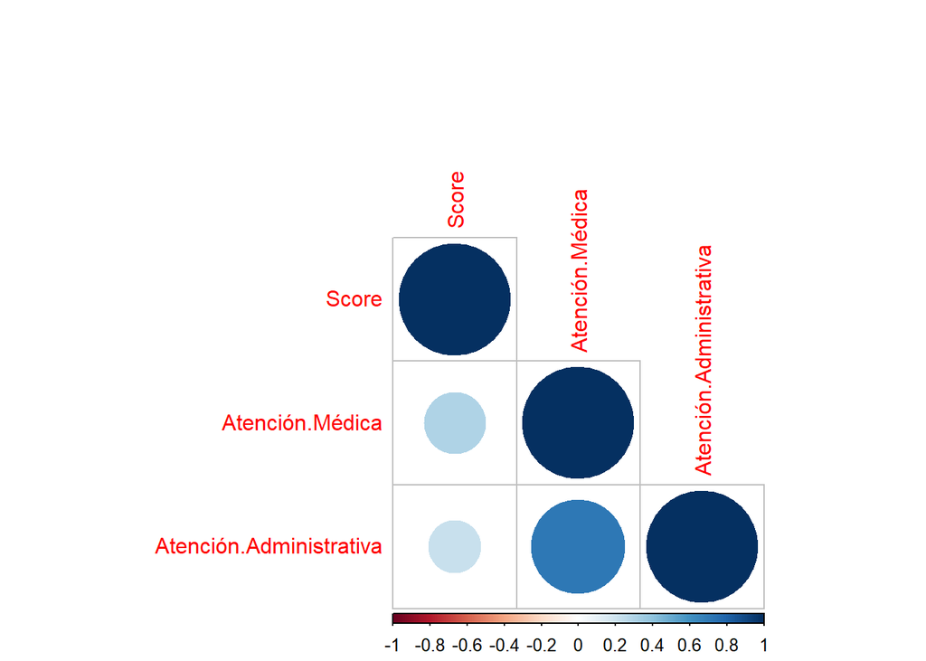

```r
corrplot(correlation_matrix, type="lower")
```